# Reproducible Research: Peer Assessment 1

# ## **MARKDOWN ASSIGNMENT**

**Assignment Instructions :**

1. Code for reading in the dataset and/or processing the data
2. Histogram of the total number of steps taken each day
3. Mean and median number of steps taken each day
4. Time series plot of the average number of steps taken
5. The 5-minute interval that, on average, contains the maximum number of steps
6. Code to describe and show a strategy for imputing missing data
7. Histogram of the total number of steps taken each day after missing values are imputed
8. Panel plot comparing the average number of steps taken per 5-minute interval across weekdays and weekends
9. All of the R code needed to reproduce the results (numbers, plots, etc.) in the report

## Loading and preprocessing the data

**Loading the data**

```r
dataset <- read.table(unz("activity.zip", "activity.csv"), header=T, quote="\"", sep=",")
dataset
```

[output not shown]

[output cut: 17554 more lines]

**Pre-processing the data**

Exploring the important aspects of the dataset :

1. Dimensions of the dataset

```r
dim(dataset)
```

```
## [1] 17568     3
```

2. Columns of the dataset

```r
names(dataset)
```

```
## [1] "steps"    "date"     "interval"
```

3. Head of the dataset

```r
head(dataset)
```

```
##   steps       date interval
## 1    NA 2012-10-01        0
## 2    NA 2012-10-01        5
## 3    NA 2012-10-01       10
## 4    NA 2012-10-01       15
## 5    NA 2012-10-01       20
## 6    NA 2012-10-01       25
```

4. Total missing data

```r
sum(is.na(dataset))
```

```
## [1] 2304
```

5. Converting the dates from character to Date

```r
library(lubridate)
dataset$date <- ymd(dataset$date)
```

6.Summary of the dataset

```r
summary(dataset)
```

```
##      steps             date               interval
##  Min.   :  0.00   Min.   :2012-10-01   Min.   :   0.0
##  1st Qu.:  0.00   1st Qu.:2012-10-16   1st Qu.: 588.8
##  Median :  0.00   Median :2012-10-31   Median :1177.5
##  Mean   : 37.38   Mean   :2012-10-31   Mean   :1177.5
##  3rd Qu.: 12.00   3rd Qu.:2012-11-15   3rd Qu.:1766.2
##  Max.   :806.00   Max.   :2012-11-30   Max.   :2355.0
##  NA's   :2304
```

## What is mean total number of steps taken per day?

**Histogram of the total number of steps taken each day**

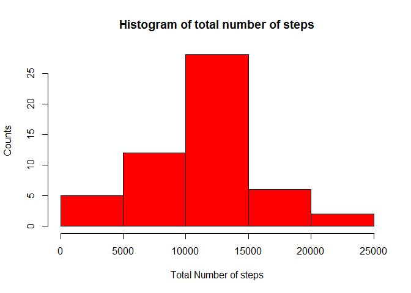

```r
totalsteps <- aggregate(steps ~ date, dataset, sum, na.rm=TRUE)
hist(totalsteps$steps , xlab = 'Total Number of steps' , ylab = 'Counts' , main = 'Histogram of total number of steps', col = 'red')
```

**Mean and median number of steps taken each day**

1.Mean number of steps taken each day

```r
meansteps <- mean(totalsteps$steps)
print('The Mean number of steps per day:')
```

```
## [1] "The Mean number of steps per day:"
```

```r
print(meansteps)
```

```
## [1] 10766.19
```

2.Median number of steps taken each day

```r
mediansteps <- median(totalsteps$steps)
print('The Median number of steps per day:')
```

```
## [1] "The Median number of steps per day:"
```

```r
print(mediansteps)
```

```
## [1] 10765
```

## What is the average daily activity pattern?

**Time series plot of the average number of steps taken**

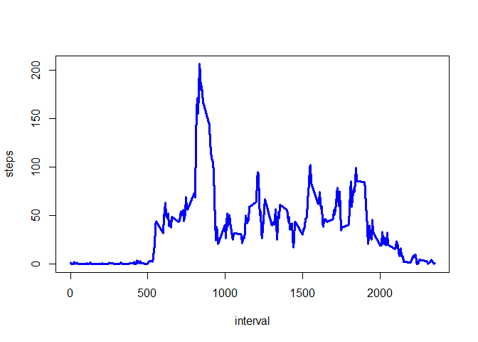

```r
stepsperinterval <- aggregate(steps ~ interval, dataset, mean, na.rm=TRUE)
plot(steps ~ interval , data = stepsperinterval , type ='l' , lwd = 3 ,col='blue')
```

**The 5-minute interval that, on average, contains the maximum number of steps**

```r
intervalfivemax <- stepsperinterval[which.max(stepsperinterval$steps),]$interval
print('The 5-minute interval that, on average, contains the maximum number of steps is:')
```

```
## [1] "The 5-minute interval that, on average, contains the maximum number of steps is:"
```

```r
print(intervalfivemax)
```

```
## [1] 835
```

## Imputing missing values

```r
missingvalues <- sum(is.na(dataset))
```

2. Impute the missing values by the average of the values and create a new dataset

```r
stepsperinterval <- tapply(dataset$steps, dataset$interval, mean, na.rm = TRUE)
dataset.split <- split(dataset, dataset$interval)
# fill in missing data for each interval
for(i in 1:length(dataset.split)){
    dataset.split[[i]]$steps[is.na(dataset.split[[i]]$steps)] <- stepsperinterval[i]
}
dataset.imputed <- do.call("rbind", dataset.split)
dataset.imputed <- dataset.imputed[order(dataset.imputed$date) ,]
```

**Histogram of the total number of steps taken each day after missing values are imputed**

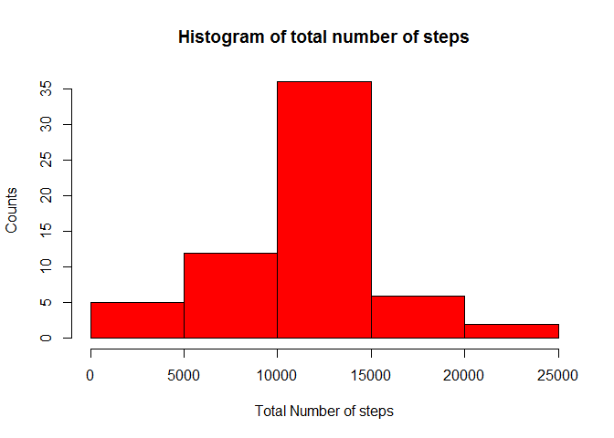

```r
totalstepsnew <- tapply(dataset.imputed$steps, dataset.imputed$date, sum)
hist(totalstepsnew , xlab = 'Total Number of steps' , ylab = 'Counts' , main = 'Histogram of total number of steps', col = 'red')
```

**Mean and median number of steps taken each day**

1.Mean number of steps taken each day

```r
meanstepsnew <- mean(totalstepsnew , na.rm = TRUE)
print('The Mean number of steps per day:')
```

```
## [1] "The Mean number of steps per day:"
```

```r
print(meanstepsnew)
```

```
## [1] 10766.19
```

2.Median number of steps taken each day

```r
medianstepsnew <- median(totalstepsnew , na.rm = TRUE)
print('The Median number of steps per day')
```

```
## [1] "The Median number of steps per day"
```

```r
print(medianstepsnew)
```

```
## [1] 10766.19
```

## Are there differences in activity patterns between weekdays and weekends?

**Panel plot comparing the average number of steps taken per 5-minute interval across weekdays and weekends**

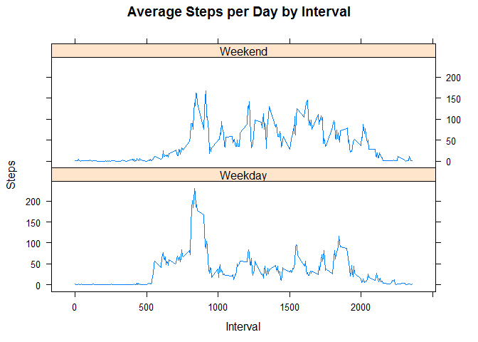

```r
weekdays <- c('Monday' , 'Tuesday' , 'Wednesday' , 'Thursday' , 'Friday')
dataset.imputed$weekday <- as.factor(ifelse(is.element(weekdays(as.Date(dataset.imputed$date)),weekdays), "Weekday", "Weekend"))
stepsnew <- aggregate(steps ~ interval + weekday , dataset.imputed, mean)
library(lattice)
xyplot(stepsnew$steps ~ stepsnew$interval|stepsnew$weekday, main="Average Steps per Day by Interval",xlab="Interval", ylab="Steps",layout=c(1,2), type="l")
```